# Biodiversity in the Great Barrier Reef - Final Project

Gabriela Cuevas & Max Baumstark

2025-11-10

# Introduction

In this report, we will investigate how environmental factors such as ocean temperature, pH level, bleaching level, latitude, and longitude impact marine biodiversity in the Great Barrier Reef. For the purposes of this report, we will use the abbreviation “GBR” for the Great Barrier Reef. Our data is assembled from various climate organization research (NOAA, GODAP, OBIS) assembled for the purpose of finding climate trends and creating future predictions. We will perform model diagnostics and multiple regression to determine which factors are most significant.

## Research Question

### How do temperature, ph level, coral bleaching level, latitude, and longitude affect marine biodiversity (number of species in a sampling region)?

# Data

Data Set: “Shifting Seas: Ocean Climate & Marine Life Dataset A Multi-Year Global Dataset of Sea Surface Temperature, pH Levels, and Corals.” Sourced from Kaggle. https://www.kaggle.com/datasets/atharvasoundankar/shifting-seas-ocean-climate-and-marine-life-dataset?resource=download

### Data Cleaning and Filtering

```
##         Date           Location Latitude Longitude   SST pH.Level
## 1 2015-01-01            Red Sea  20.0248   38.4931 29.47    8.107
## 2 2015-01-07 Great Barrier Reef -18.2988  147.7782 29.65    8.004
## 3 2015-01-14      Caribbean Sea  14.9768  -75.0233 28.86    7.947
## 4 2015-01-20 Great Barrier Reef -18.3152  147.6486 28.97    7.995
## 5 2015-01-27          Galápagos  -0.8805  -90.9769 28.60    7.977
## 6 2015-02-02            Red Sea  20.0055   38.4425 29.06    8.009
##   Bleaching.Severity Species.Observed Marine.Heatwave
## 1               None              106           FALSE
## 2               High              116           FALSE
## 3               High               90           FALSE
## 4             Medium               94           FALSE
## 5               None              110           FALSE
## 6                Low              109           FALSE
```

```
## [1] 500   9
```

Before cleaning our data, we have exactly 500 observations observed over many different locations across the globe.

To better understand our dataset, we want to specifically look at the Great Barrier Reef.

Also, we are going to rename the SST column to temperature, eliminate the marine heatwave predictor, and eliminate any null observations.

We also want to mention that latitude and longitude are constrained to the general region of the GBR, so they are discrete variables.

```
##         Date           Location Latitude Longitude temperature    pH
## 1 2015-01-07 Great Barrier Reef -18.2988  147.7782       29.65 8.004
## 2 2015-01-20 Great Barrier Reef -18.3152  147.6486       28.97 7.995
## 3 2015-05-12 Great Barrier Reef -18.3579  147.6782       27.99 8.020
## 4 2015-05-25 Great Barrier Reef -18.3830  147.6979       28.59 8.171
## 5 2015-06-01 Great Barrier Reef -18.2720  147.6975       26.75 8.142
## 6 2015-07-24 Great Barrier Reef -18.3228  147.7925       29.21 7.976
##   bleachLevel species
## 1        High     116
## 2      Medium      94
## 3        None     122
## 4      Medium     116
## 5      Medium     148
## 6        High     122
```

```
## [1] 87  8
```

After cleaning the data, there are 87 observations pertaining to our geographic region of interest, The Great Barrier Reef.

Now, we have to create dummy variables in order to indicate the severity of the bleaching level in the Great Barrier Reef.

### Creating Dummy for Bleach Level

```r
GBR_dat$highBleach <- ifelse(GBR_dat$bleachLevel == "High", 1, 0)
GBR_dat$mediumBleach <- ifelse(GBR_dat$bleachLevel == "Medium", 1, 0)
GBR_dat$lowBleach <- ifelse(GBR_dat$bleachLevel == "Low", 1, 0)
GBR_dat <- GBR_dat %>%
  select (-bleachLevel)

head(GBR_dat)
```

```
##         Date           Location Latitude Longitude temperature    pH species
## 1 2015-01-07 Great Barrier Reef -18.2988  147.7782       29.65 8.004     116
## 2 2015-01-20 Great Barrier Reef -18.3152  147.6486       28.97 7.995      94
## 3 2015-05-12 Great Barrier Reef -18.3579  147.6782       27.99 8.020     122
## 4 2015-05-25 Great Barrier Reef -18.3830  147.6979       28.59 8.171     116
## 5 2015-06-01 Great Barrier Reef -18.2720  147.6975       26.75 8.142     148
## 6 2015-07-24 Great Barrier Reef -18.3228  147.7925       29.21 7.976     122
##   highBleach mediumBleach lowBleach
## 1          1            0         0
## 2          0            1         0
## 3          0            0         0
## 4          0            1         0
## 5          0            1         0
## 6          1            0         0
```

After the data has been cleaned, we are able to move on to the methods of our project.

# Methods

## Fitting a Multiple Regression Model

```r
lm_ocean_full <- lm(species ~ temperature + pH + Latitude + Longitude + highBleach + mediumBleach + lowBleach, data = GBR_dat)
summary(lm_ocean_full)
```

```
##
## Call:
## lm(formula = species ~ temperature + pH + Latitude + Longitude +
##     highBleach + mediumBleach + lowBleach, data = GBR_dat)
##
## Residuals:
##     Min      1Q  Median      3Q     Max
## -22.404 -10.634  -0.592   7.027  35.567
##
## Coefficients:
##                Estimate Std. Error t value Pr(>|t|)
## (Intercept)  -5570.5744  4334.6007  -1.285    0.202
## temperature     -9.7432     1.2656  -7.698 3.36e-11 ***
## pH             -10.1908    29.5325  -0.345    0.731
## Latitude        16.3202    29.9583   0.545    0.587
## Longitude       43.0045    28.5684   1.505    0.136
## highBleach       0.2286     4.6217   0.049    0.961
## mediumBleach    -2.6331     3.8915  -0.677    0.501
## lowBleach       -2.0113     3.8860  -0.518    0.606
## ---
## Signif. codes:  0 '***' 0.001 '**' 0.01 '*' 0.05 '.' 0.1 ' ' 1
##
## Residual standard error: 13.5 on 79 degrees of freedom
## Multiple R-squared:  0.4895, Adjusted R-squared:  0.4443
## F-statistic: 10.82 on 7 and 79 DF,  p-value: 1.719e-09
```

Our initial summary indicates that temperature is the only significant predictor (as it is the only predictor value below any reasonable significance level). The other predictor that has a relatively low p-value is longitude, but we will take a closer look into the significant predictors in the future.

## Full Model

We consider the following regression model:

$$\text{Species}_i
= \beta_0
+ \beta_1 \text{temperature}_i
+ \beta_2 \text{longitude}_i
+ \beta_3 \text{latitude}_i
+ \beta_4 \text{pH}_i
+ \beta_5 \text{highBleach}_i
+ \beta_6 \text{mediumBleach}_i
+ \beta_7 \text{lowBleach}_i
+ \epsilon_i$$

Where:

#### Error term assumptions:

$$\epsilon_i \overset{\text{iid}}{\sim} N(0, \sigma^2),$$

- **Independence**: the $\epsilon_i$ are independent across observations
- **Mean zero**: $E[\epsilon_i] = 0$
- **Constant variance** (homoscedasticity): $\text{Var}(\epsilon_i) = \sigma^2$ for all $i$
- **Normality**: $\epsilon_i$ are normally distributed

### *Full Model Coefficients:*

##### Intercept = -5570.5744

- The intercept coefficient is not meaningful. There is no case in which there will be a negative number of species in the the GBR.

##### Temperature = -9.7432

- For each 1°C increase in sea temperature, the expected number of species decreases by about 9.7, holding all other predictors constant.

##### Latitude = 16.3202

- Moving 1° north is associated with about 16 more species, but this effect is not statistically significant.

##### Longitude = 43.0045

- A 1° eastward change is associated with 43 additional species

##### Bleaching (all coefficients < |3| and p > 0.5)

- Compared to sites with no observed bleaching, none of the bleaching levels show a meaningful difference in species count. High bleaching shows essentially no change in species richness, while medium and low bleaching are associated with 2–3 fewer species, but none of these effects are statistically significant. Overall, bleaching level does not appear to be a strong predictor of species richness in this model.

## *Observations:*

The R-Squared values suggest that there is a moderate correlation between the predictors and and the number of species in the GBR. There is also a difference of about 0.045 between the R-Squared and the Adjusted R-Squared, suggesting a strong penalty induced by including so many predictors.

Next, let’s make sure no model assumptions are being violated, and make any transformations if needed.

## Assumptions & Diagnostics

First, we are going to make a visual representation of the predicted vs. observed values.

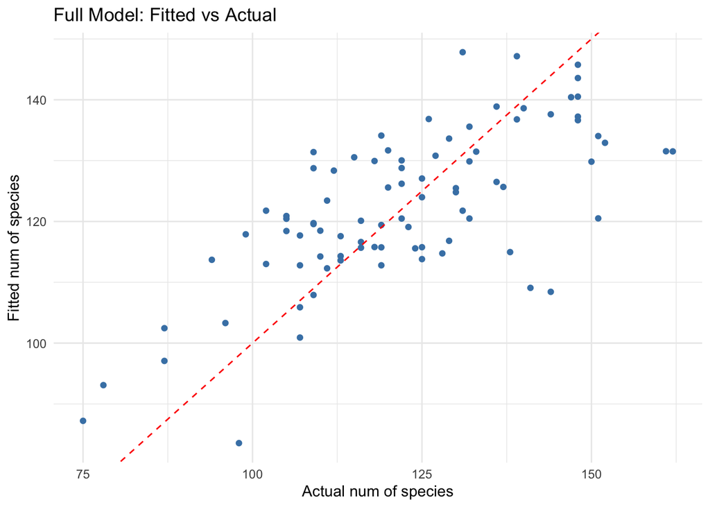

There aren’t any glaring obscurities when it comes to observed values deviating from the predicted values, so we can move into checking individual assumptions.

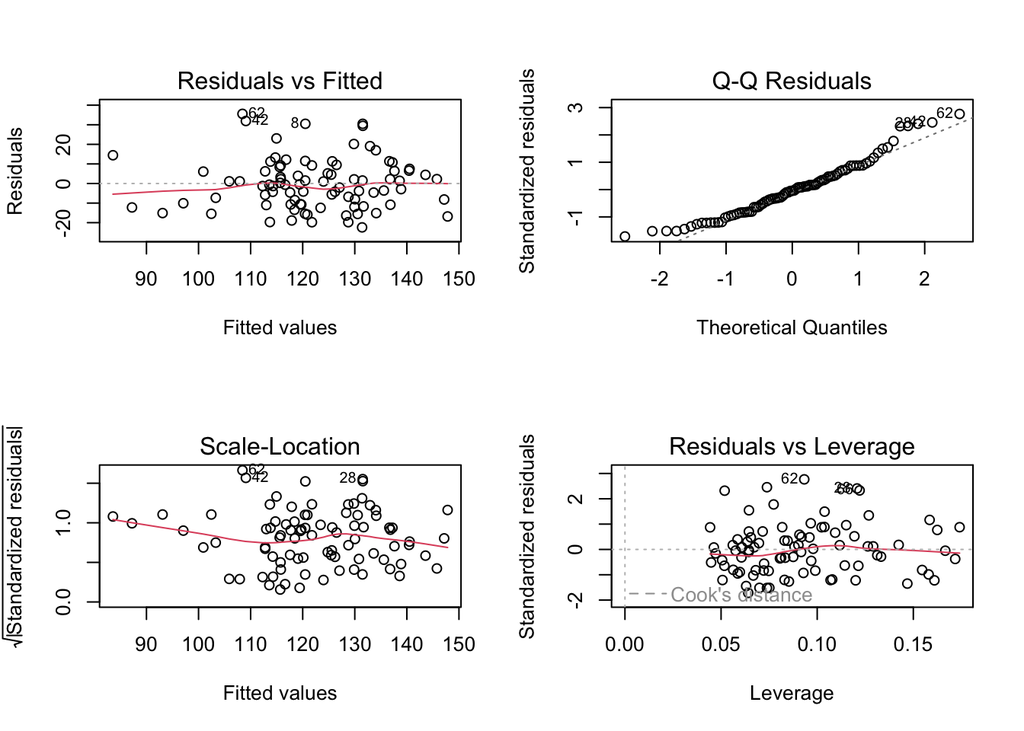

```r
par(mfrow = c(2, 2))
plot(lm_ocean_full)
```

#### *Linearity:*

The linearity assumption does not appear to be violated as the vertical scatter of points in the residuals vs. fitted plot seems to be random scattered around zero.

#### *Independence of Errors:*

Each observation was collected on a different date and represents a separate measurement from an independent subject/time point, making it unlikely that the measurement from one day influenced the next.

#### *Constant Variance:*

On the Scale-Location plot, we can see that on the tails, there is moderate variation from the horizontal line in the center, but nothing too serious. We will keep this in mind when completing the Breusch-Pagan test.

```r
bptest(lm_ocean_full)
```

```
##
##  studentized Breusch-Pagan test
##
## data:  lm_ocean_full
## BP = 4.7261, df = 7, p-value = 0.6933
```

p-value: 0.6933

Since the p-value is greater than any reasonable significance level, we can conclude that the constant variance assumption remains intact.

#### *Normality:*

Looking at the Q-Q Plot above, there is slight variation at the tails of the plot, and these observations are designated as possible influential points. This is something to keep in mind when we check for influential points later on. Next, we can conduct a Shapiro-Wilk test for normality.

```r
shapiro.test(residuals(lm_ocean_full))
```

```
##
##  Shapiro-Wilk normality test
##
## data:  residuals(lm_ocean_full)
## W = 0.961, p-value = 0.01018
```

The Shapiro-Wilk test indicates that the residuals deviate from normality. We can also perform the Anderson-Darling test for Normality.

```r
ad.test(lm_ocean_full$residuals)
```

```
##
##  Anderson-Darling normality test
##
## data:  lm_ocean_full$residuals
## A = 0.71226, p-value = 0.06085
```

The Anderson-Darling normality test suggests that the normality assumption is not being violated. Since we have conflicting tests, we should check for influential points now so we can determine if these are what is causing the lack of normality.

#### *Removing Outliers?*

Residuals vs Leverage

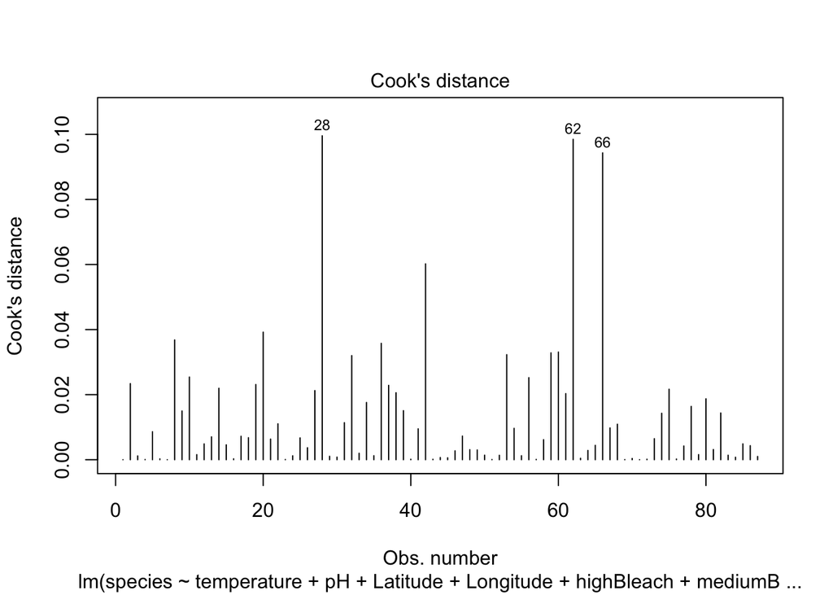

```r
plot(lm_ocean_full, which = 4)
```

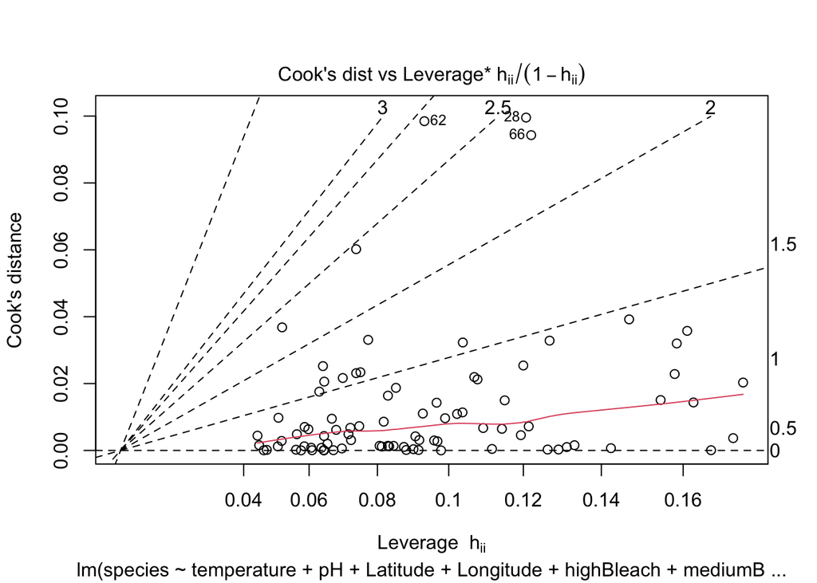

```r
plot(lm_ocean_full, which = 6)
```

The Cook’s Distance plot suggests that observations 28, 62, and 66 are highly influential points.

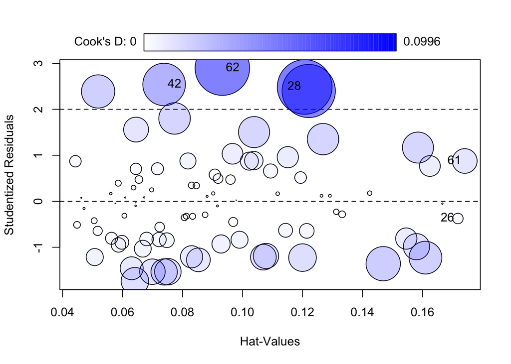

```
##       StudRes        Hat       CookD
## 26 -0.3744341 0.17178510 0.003674988
## 28  2.4862106 0.12072289 0.099554628
## 42  2.5406556 0.07385770 0.060189644
## 61  0.8766249 0.17408218 0.020306252
## 62  2.8937672 0.09327018 0.098479702
```

```r
influencePlot(lm_ocean_full)
```

We can look into the hat values of every value.

```r
lev <- hatvalues(lm_ocean_full)
lev
```

```
##          1          2          3          4          5          6          7
## 0.09788131 0.07510297 0.08125734 0.16662193 0.08180498 0.12632825 0.06443694
##          8          9         10         11         12         13         14
## 0.05185945 0.11509344 0.11999178 0.04482633 0.05632481 0.05865828 0.10695455
##         15         16         17         18         19         20         21
## 0.11935503 0.12912579 0.12141218 0.07217382 0.07386827 0.14689424 0.05977446
##         22         23         24         25         26         27         28
## 0.09283477 0.06721762 0.05054558 0.10934636 0.17178510 0.10781577 0.12072289
##         29         30         31         32         33         34         35
## 0.08753203 0.06061485 0.10375774 0.15847705 0.06545565 0.06304359 0.08335737
##         36         37         38         39         40         41         42
## 0.16097164 0.15797531 0.06450788 0.15458288 0.08818889 0.06674851 0.07385770
##         43         44         45         46         47         48         49
## 0.09163626 0.14238566 0.06970265 0.09689319 0.07475736 0.07237462 0.09598759
##         50         51         52         53         54         55         56
## 0.08301287 0.06089165 0.08460308 0.10384472 0.09900467 0.05855853 0.06412624
##         57         58         59         60         61         62         63
## 0.06435064 0.06802454 0.12683630 0.07733984 0.17408218 0.09327018 0.11171094
##         64         65         66         67         68         69         70
## 0.05170950 0.04429581 0.12205961 0.05073441 0.10227545 0.04624015 0.09022349
##         71         72         73         74         75         76         77
## 0.05758154 0.04716003 0.11434689 0.09665869 0.06996068 0.05607549 0.09076021
##         78         79         80         81         82         83         84
## 0.08301136 0.13320954 0.08528346 0.09184733 0.16245948 0.08062408 0.06366201
##         85         86         87
## 0.07163662 0.06445513 0.13125002
```

```r
lev[lev > (2*(7+1)/87)]
```

```
## named numeric(0)
```

The hat value test suggests that no values differ too greatly as influential points.

Studentized Residuals will be the next thing we to look into.

```r
r <- rstudent(lm_ocean_full)
r
```

```
##           1           2           3           4           5           6
##  0.02447558 -1.53047850 -0.32291827 -0.05008950  0.87723568  0.11974595
##           7           8           9          10          11          12
## -0.03151729  2.38837198  0.95921965 -1.22463526 -0.51189214 -0.80442466
##          13          14          15          16          17          18
## -0.94867912 -1.21463893  0.51660947  0.12022579 -0.64285135 -0.83206757
##          19          20          21          22          23          24
## -1.53528839 -1.35673411 -0.89160232 -0.92781912  0.08434941 -0.42247779
##          25          26          27          28          29          30
##  0.65878474 -0.37443413 -1.18899825  2.48621063 -0.29325787 -0.31264684
##          31          32          33          34          35          36
##  0.88514247  1.16849847  0.47340960 -1.45609941 -0.32652753 -1.22492197
##          37          38          39          40          41          42
## -0.98688364  1.55915124 -0.81022170  0.10717854 -1.03022884  2.54065563
##          43          44          45          46          47          48
## -0.10083974  0.17808609  0.24848957 -0.44915716 -0.84639483 -0.55937609
##          49          50          51          52          53          54
##  0.47181498  0.34826130  0.08263081  0.34073974  1.50474046 -0.83583626
##          55          56          57          58          59          60
##  0.39423570 -1.73769965 -0.09860250 -0.81940275  1.35178694  1.80189882
##          61          62          63          64          65          66
##  0.87662491  2.89376721  0.16607711 -0.64304507  0.87150570  2.39857408
##          67          68          69          70          71          72
## -1.21248967  0.87369534  0.07648893  0.17135013 -0.04488846 -0.15554980
##          73          74          75          76          77          78
## -0.63029031  1.03344900 -1.53057137  0.16708305  0.57884099 -1.20662800
##          79          80          81          82          83          84
## -0.28326072 -1.27237027  0.49404363  0.76733105 -0.35201701  0.29763464
##          85          86          87
##  0.70756761  0.70487087 -0.22813854
```

The observations with the largest studentized residual values: 8, 28, 42, 62, and 66.

All of these observations have studentized residual values above 2, flagging them as possible outliers.

After running these tests, there are no points that are suggested as outliers throughout each test, and no points that show extreme values when it comes to individual test results. Therefore, removal of any observation is not necessary in this case, but it will be a good idea to look into different transformations.

So, our influential points assumption holds, and we can look back to our normality assumption.

#### *Normality re-check*

The more important test for normality is the Normal Q-Q Plot, which suggests that the normality assumption is met. The next assumption to be checked is the existence of multicollinearity.

#### *Multicollinearity*

```r
vif(lm_ocean_full)
```

```
##  temperature           pH     Latitude    Longitude   highBleach mediumBleach
##     1.251372     1.249345     1.029854     1.049436     1.377493     1.444890
##    lowBleach
##     1.440777
```

All of our predictors have a VIF value below 1.5, which suggests no existence of multicollinearity.

#### *No Important Predictors Omitted:*

The predictor that we removed was Marine Heatwave. We removed this due to a lack of observations that were indicated as being during a marine heatwave, and to avoid multicollinearity with the temperature predictor.

#### *Possible Lack-of-Fit:*

The lack-of-fit assumption was evaluated using the Residuals vs. Fitted plot. The residuals showed no systematic patterns or curvature, indicating that a linear model provides an adequate description of the relationships in the data.

Since the dataset does not contain replicated predictor values, a formal lack-of-fit test could not be performed. Overall, there is no visual evidence of lack of fit, and the linear model form appears appropriate.

#### *What if we removed the influential observations?*

While we decided not to remove the influential points in this project, it is still a good idea to get an idea of what the rest of the data looks like without the outliers. Below, we have removed the five most influential points, and completed an analysis on what was left.

```r
influential_indices <- c(28, 42, 61, 62, 66)
GBR_filtered <- GBR_dat[-influential_indices, ]
lm_ocean_filtered <- lm(species ~ temperature + pH + Latitude + Longitude + highBleach + mediumBleach + lowBleach, data = GBR_filtered)
summary(lm_ocean_full)
```

```
##
## Call:
## lm(formula = species ~ temperature + pH + Latitude + Longitude +
##     highBleach + mediumBleach + lowBleach, data = GBR_dat)
##
## Residuals:
##     Min      1Q  Median      3Q     Max
## -22.404 -10.634  -0.592   7.027  35.567
##
## Coefficients:
##                Estimate Std. Error t value Pr(>|t|)
## (Intercept)  -5570.5744  4334.6007  -1.285    0.202
## temperature     -9.7432     1.2656  -7.698 3.36e-11 ***
## pH             -10.1908    29.5325  -0.345    0.731
## Latitude        16.3202    29.9583   0.545    0.587
## Longitude       43.0045    28.5684   1.505    0.136
## highBleach       0.2286     4.6217   0.049    0.961
## mediumBleach    -2.6331     3.8915  -0.677    0.501
## lowBleach       -2.0113     3.8860  -0.518    0.606
## ---
## Signif. codes:  0 '***' 0.001 '**' 0.01 '*' 0.05 '.' 0.1 ' ' 1
##
## Residual standard error: 13.5 on 79 degrees of freedom
## Multiple R-squared:  0.4895, Adjusted R-squared:  0.4443
## F-statistic: 10.82 on 7 and 79 DF,  p-value: 1.719e-09
```

```r
summary(lm_ocean_filtered)
```

```
##
## Call:
## lm(formula = species ~ temperature + pH + Latitude + Longitude +
##     highBleach + mediumBleach + lowBleach, data = GBR_filtered)
##
## Residuals:
##      Min       1Q   Median       3Q      Max
## -21.2463  -9.3075   0.4459   6.6625  29.5934
##
## Coefficients:
##                Estimate Std. Error t value Pr(>|t|)
## (Intercept)  -8.626e+03  3.719e+03  -2.319   0.0231 *
## temperature  -9.839e+00  1.095e+00  -8.982  1.8e-13 ***
## pH           -1.634e+01  2.553e+01  -0.640   0.5241
## Latitude      1.637e+00  2.822e+01   0.058   0.9539
## Longitude     6.221e+01  2.458e+01   2.531   0.0135 *
## highBleach   -3.432e+00  4.152e+00  -0.826   0.4112
## mediumBleach -2.110e+00  3.424e+00  -0.616   0.5396
## lowBleach    -2.198e-02  3.356e+00  -0.007   0.9948
## ---
## Signif. codes:  0 '***' 0.001 '**' 0.01 '*' 0.05 '.' 0.1 ' ' 1
##
## Residual standard error: 11.38 on 74 degrees of freedom
## Multiple R-squared:  0.5905, Adjusted R-squared:  0.5517
## F-statistic: 15.24 on 7 and 74 DF,  p-value: 3.561e-12
```

When the influential points are removed from the model, longitude is much more significant. This suggests that the further east one travels across the GBR, the greater the number of species will be.

Also, the predictors explain much more of the data as the Adjusted R-Squared bumps up from 0.44 to 0.55. This is a significant increase in the performance of the model.

One may wonder, if the model fits better, why would we not simply remove the data points?

In regression, we want to avoid ‘choosing’ what data to include in models as much as possible, otherwise we are not providing a true representative of the population we are trying to model. Observations should only be removed if they are extreme, and we have determined that these observations are not extreme.

##### Coefficients of the Full Model and Filtered Model

```
##                Full_Model Filtered_Model
## (Intercept)  -5570.574417  -8.626058e+03
## temperature     -9.743178  -9.838949e+00
## pH             -10.190793  -1.634221e+01
## Latitude        16.320227   1.637459e+00
## Longitude       43.004469   6.221372e+01
## highBleach       0.228565  -3.431699e+00
## mediumBleach    -2.633083  -2.110098e+00
## lowBleach       -2.011302  -2.198077e-02
```

# Model Selection

*Box-Cox Plot*

Since a few assumptions/diagnostics were not entirely convincing, we should look at a box-cox plot to see if a transformation is necessary

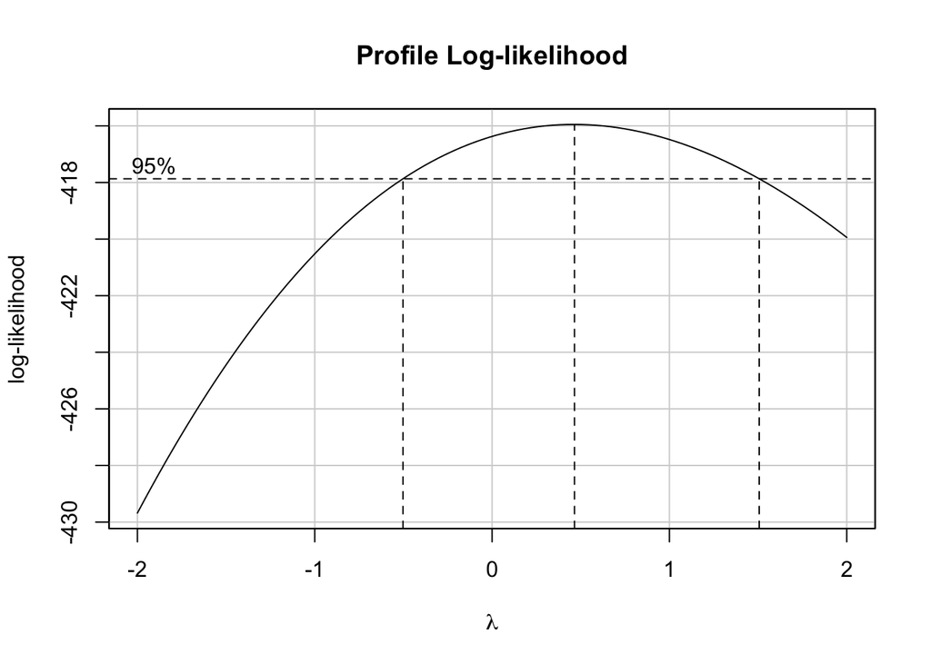

```r
boxCox(lm_ocean_full)
```

The box-cox plot shows that a square root transformation would be beneficial to this dataset.

```r
sqrt_ocean <- lm(sqrt(species)  ~ temperature + pH + Latitude + Longitude + highBleach + mediumBleach + lowBleach, data = GBR_dat)
summary(sqrt_ocean)
```

```
##
## Call:
## lm(formula = sqrt(species) ~ temperature + pH + Latitude + Longitude +
##     highBleach + mediumBleach + lowBleach, data = GBR_dat)
##
## Residuals:
##      Min       1Q   Median       3Q      Max
## -1.00932 -0.47067  0.00977  0.31047  1.62021
##
## Coefficients:
##                Estimate Std. Error t value Pr(>|t|)
## (Intercept)  -2.437e+02  1.958e+02  -1.245    0.217
## temperature  -4.528e-01  5.718e-02  -7.920 1.25e-11 ***
## pH           -4.397e-01  1.334e+00  -0.330    0.743
## Latitude      6.582e-01  1.353e+00   0.486    0.628
## Longitude     1.918e+00  1.291e+00   1.486    0.141
## highBleach    7.182e-04  2.088e-01   0.003    0.997
## mediumBleach -1.273e-01  1.758e-01  -0.724    0.471
## lowBleach    -1.036e-01  1.756e-01  -0.590    0.557
## ---
## Signif. codes:  0 '***' 0.001 '**' 0.01 '*' 0.05 '.' 0.1 ' ' 1
##
## Residual standard error: 0.6097 on 79 degrees of freedom
## Multiple R-squared:  0.5033, Adjusted R-squared:  0.4593
## F-statistic: 11.44 on 7 and 79 DF,  p-value: 6.196e-10
```

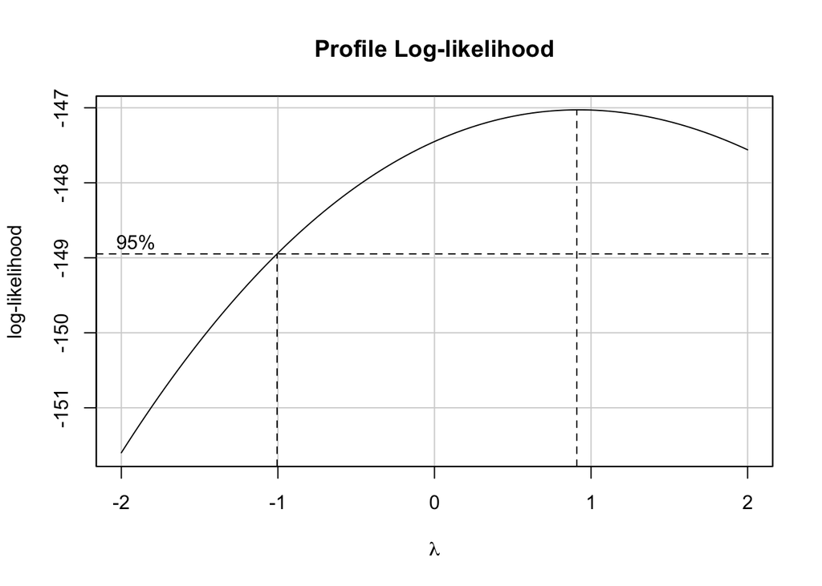

```r
boxCox(sqrt_ocean)
```

The transformed data’s lambda value is approximately one, which is exactly what we want to see. Let’s compare assumptions/diagnostics of the square rooted data compared to the original data.

### Visualize all predictors

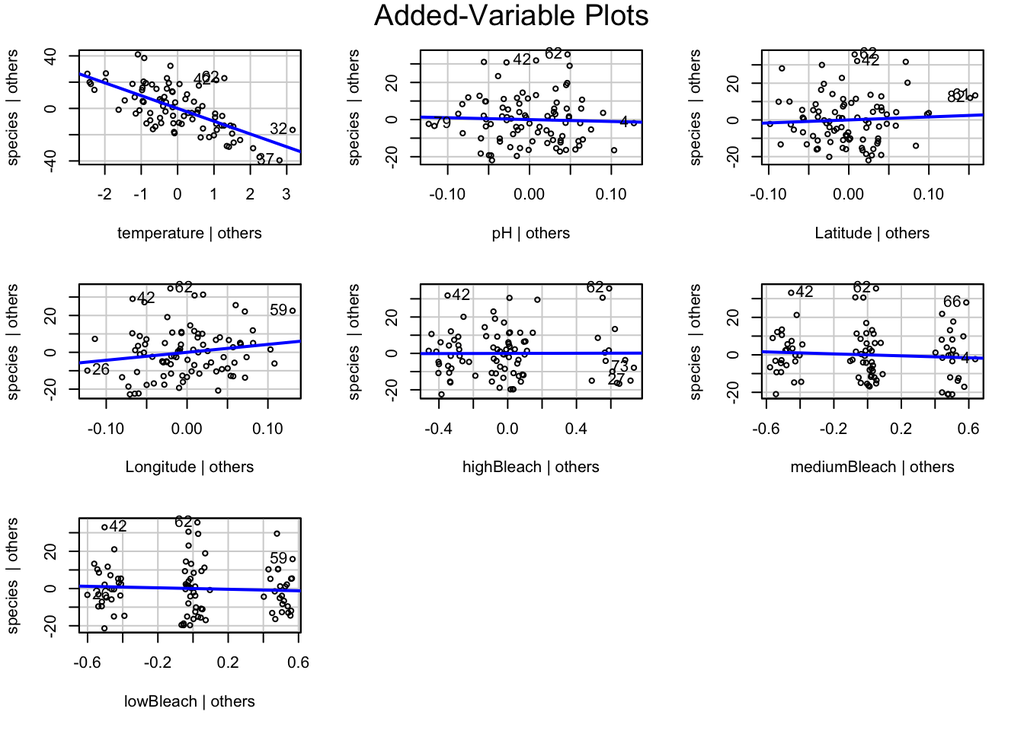

```r
avPlots(lm_ocean_full)
```

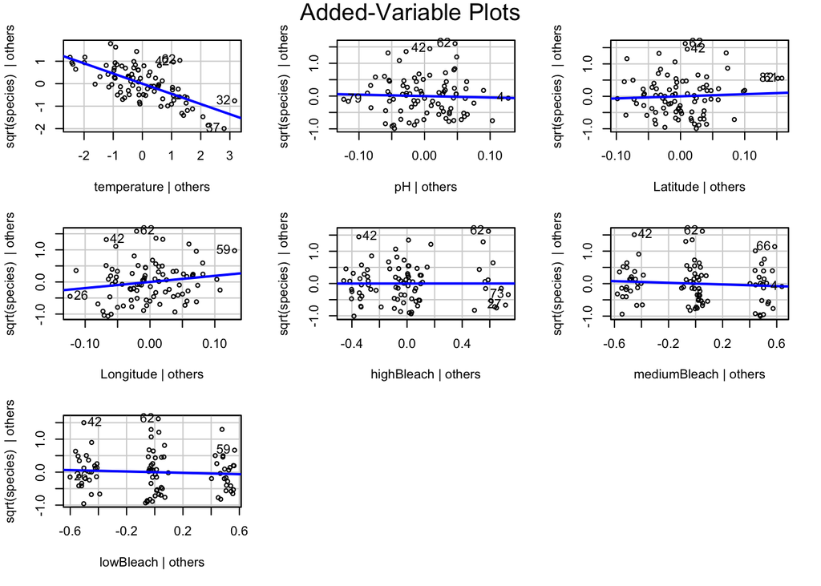

```r
avPlots(sqrt_ocean)
```

The added variable plots are almost identical between the two models, so any conclusions can be shared between both models.

```
##               Model bp_p_value sw_p_value ad_p_value max_vif
## 1        Full Model  0.6933469 0.01018056  0.0608545 1.44489
## 2 Square Root Model  0.5388011 0.03564228  0.1676837 1.44489
```

All of the test results from the Breusch-Pagan test, Shapiro-Wilk test, Anderson-Darling test, and vif values do not vary enough between models to designate one over another.

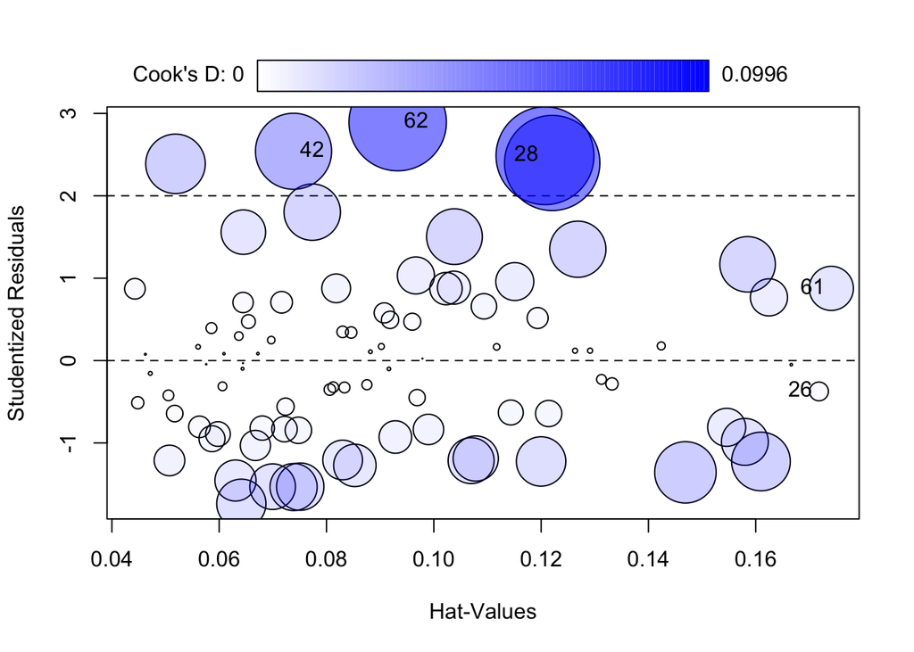

```
##       StudRes        Hat       CookD
## 26 -0.3744341 0.17178510 0.003674988
## 28  2.4862106 0.12072289 0.099554628
## 42  2.5406556 0.07385770 0.060189644
## 61  0.8766249 0.17408218 0.020306252
## 62  2.8937672 0.09327018 0.098479702
```

```r
influencePlot(lm_ocean_full)
```

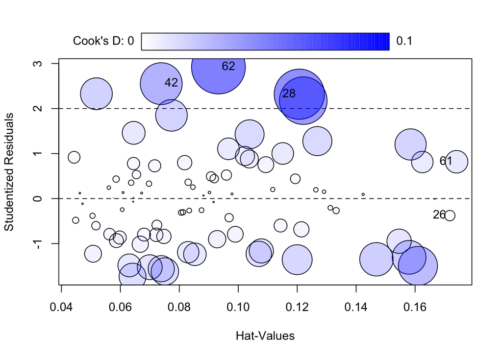

```
##       StudRes        Hat       CookD
## 26 -0.3785829 0.17178510 0.003756727
## 28  2.3181547 0.12072289 0.087388840
## 42  2.5531365 0.07385770 0.060736733
## 61  0.8178196 0.17408218 0.017695668
## 62  2.9204899 0.09327018 0.100126824
```

```r
influencePlot(sqrt_ocean)
```

Again, there are very minimal differences between the studentized residuals, hat values, and cook’s distance values, so we can keep the same conclusions we drew for the original model.

### Original Data Vs. Transformed Data Assumptions

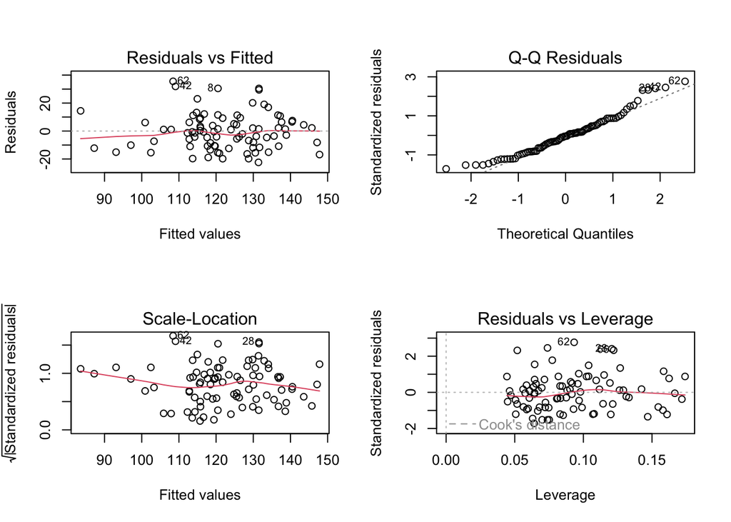

```r
par(mfrow = c(2, 2))
plot(lm_ocean_full)
```

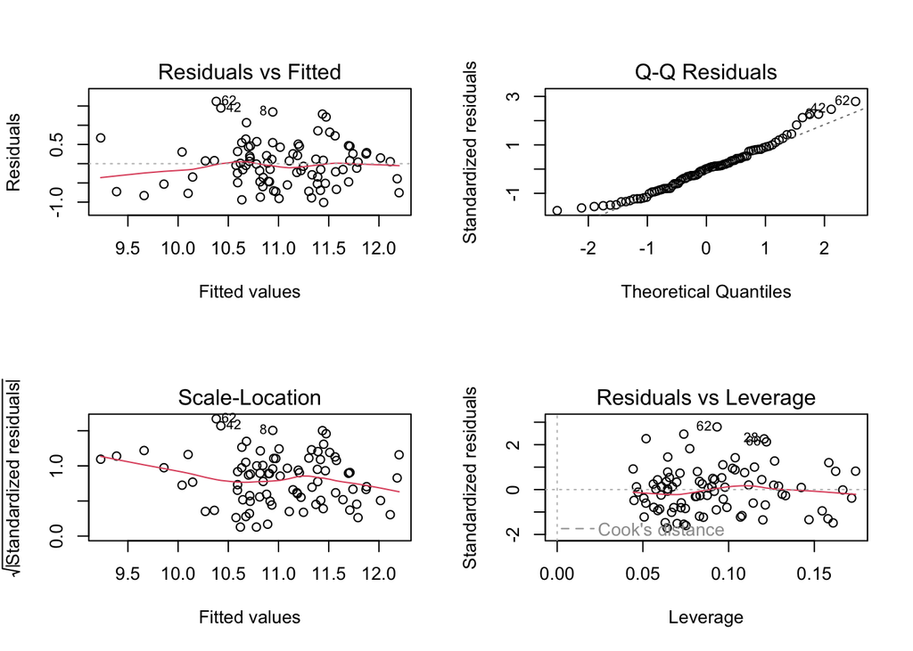

```r
plot(sqrt_ocean)
```

The diagnostic plots look almost identical, so these can not be used to distinguish between the models.

### Compare AIC and Adjusted R²

```
##   Model    Adj_R2      AIC      BIC
## 1  sqrt 0.4593414 170.4213 192.6145
## 2  Full 0.4442633 709.3262 731.5193
```

The AIC and BIC values are the biggest indicator as there is a greater than 3x increase in both AIC and BIC in the full model compared to the transformed model.

For these reasons, we can move forward with the conclusion that the transformed model fits our data better than the original model.

```
##      Model    Adj_R2      AIC      BIC
## 1  Forward 0.4700659 700.5291 710.3927
## 2 Backward 0.4844323 161.6263 171.4899
## 3 Stepwise 0.4700659 700.5291 710.3927
```

*Temperature & Longitude*

### More Candidate Models

$$\sqrt{\text{species}_i}
= \beta_0
+ \beta_1 \, \text{temperature}_i
+ \beta_2 \, \text{longitude}_i
+ \epsilon_i$$

$$\sqrt{\text{species}_i}
= \beta_0
+ \beta_1 \, \text{temperature}_i
+ \epsilon_i$$

Where:

- $\sqrt{\text{species}}$ = the response variable (square root of the number of species) for site $i$
- $X_{1i}, X_{2i}, \ldots, X_{7i}$ = predictor variables for site $i$, where:
  - $X_{1i}$: temperature
  - $X_{2i}$: longitude
- $\epsilon_i$ = random error term with $E[\epsilon_i] = 0$ and $\text{Var}(\epsilon_i)=\sigma^2$

```
##                     Model    Adj_R2      AIC      BIC
## 1 Temperature + Longitude 0.4844323 161.6263 171.4899
## 2        Temperature Only 0.4733213 162.5109 169.9086
```

### Model Statistic Comparisions:

The adjusted r-squared values are almost identical between the two models (0.4844 and 0.4733) suggesting that the simpler model is the one we should go with.

The F-statistic for the simpler model is almost 2x greater than the F-statistic of the model that includes longitude (41.4 and 78.29). This suggests that the simpler model explains more of the variance compared to the random noise.

There is not a difference in AIC or BIC greater than two between the models, meaning that AIC and BIC both suggest going with the simpler model.

### Partial F-Test

```
## Analysis of Variance Table
##
## Model 1: sqrt(species) ~ temperature + Longitude
## Model 2: sqrt(species) ~ temperature
##   Res.Df    RSS Df Sum of Sq      F  Pr(>F)
## 1     84 29.780
## 2     85 30.784 -1    -1.004 2.8318 0.09613 .
## ---
## Signif. codes:  0 '***' 0.001 '**' 0.01 '*' 0.05 '.' 0.1 ' ' 1
```

Our partial F-Test indicates that we lack sufficient evidence to reject the null hypothesis we have a p-value greater than 0.05. This test indicates that there is not a significant difference between the models, and that the simpler model should be selected to avoid over-fitting.

### Final Model Selection

Taking all these statistics into consideration, the decision to go with the simple model seems very self-explanatory. We have decided to go against what the model selection functions said to keep the model as simple as possible, while still keeping as much explanation of variability as we can.

So, our final model is made up of only one predictor with a square-root transformation, temperature to predict the number of species in a given area.

# Results

### Interpretation of the summary output

#### Final Model

$$\sqrt{\text{species}_i}
= \beta_0
+ \beta_1 \, \text{temperature}_i
+ \epsilon_i$$

```
##
## Call:
## lm(formula = sqrt(species) ~ temperature, data = GBR_dat)
##
## Residuals:
##      Min       1Q   Median       3Q      Max
## -1.11285 -0.42349 -0.07463  0.34684  1.64261
##
## Coefficients:
##             Estimate Std. Error t value Pr(>|t|)
## (Intercept) 23.73932    1.43765  16.513  < 2e-16 ***
## temperature -0.44636    0.05045  -8.848  1.1e-13 ***
## ---
## Signif. codes:  0 '***' 0.001 '**' 0.01 '*' 0.05 '.' 0.1 ' ' 1
##
## Residual standard error: 0.6018 on 85 degrees of freedom
## Multiple R-squared:  0.4794, Adjusted R-squared:  0.4733
## F-statistic: 78.29 on 1 and 85 DF,  p-value: 1.097e-13
```

Intercept: 23.73932 - The intercept represents the expected value of $\sqrt{\text{Species}}$ when temperature = 0°C. Because 0°C is far outside the observed temperature range (26–32°C), this value is not meaningful in context.

temperature: -0.44636 - For each 1°C increase in temperature, the **square root** of the expected species count decreases by 0.446 units.

R-Squared: 0.4794 - about 48% of the variation in our data can be described by the temperature (degrees celsius) at that location.

F-Statistic: 78.29 & p-value: 1.097e-13 - These values are significant, meaning that we can reject the null hypothesis that the predictors do not fit the data.